# Lecture 2: R basics

September, 2015

## Today

- R basics
- groups
- exercise 1

## R basics

- do you all have R installed on your computer?
- can you all read datasets into R?
- have you finished exercise 1?

## Installing packages

- on its own, R can't do all that much
- to really make use of R's capabilities, we need packages
- a package bundles together code, data, documentation, and tests
- we install packages from two sources
  - the Comprehensive R Archive Network (CRAN)
  - github

## Installing packages from CRAN

We can install the `readr` package, for example, by running

```r
install.packages("readr")
```

Afterwards, we can access all the functions available in the package by running

```r
library("readr")
```

## Installing packages from Github

It's slightly more difficult to install from github since we need to load a package from CRAN first: `devtools`

Installing from Github now looks like

```r
library("devtools")
install_github("hadley/purrr")
```

the `purrr` package can now be loaded using the `library` command

```r
library("purrr")
```

## Getting help

- if you know the command, type `?` followed by the function in the console

```r
?summary
```

- search your version of R using `??` followed by the function name
- otherwise, try Google/Stackoverflow or our discussion forum

## Fundamentals

R is *object oriented*

Examples:

- character string (e.g. words)
- number
- vector
- matrix
- data frame
- list

We can verify the class of an object using the `class` function

We assign objects to object names using "`<-`" or "`=`"

## Example

```r
z = "text"
p = c(1, 3, 5)
q = 2
y = NA
k = FALSE
```

- **Question**: what is the class of the objects given above?

## Special values

- `NA`: not avaliable, missing (`is.na`)
- `NULL`: undefined (`is.null`)
- `TRUE`: logical true (`isTRUE`)
- `FALSE`: logical false (`!isTRUE`)

## Symbols

| Operator | Meaning |
| --- | --- |
| `<` | less than |
| `>` | greater than |
| `==` | equal to |
| `<=` | less than or equal to |
| `>=` | greater than or equal to |
| `!=` | not equal to |
| `a \| b` | a or b |
| `a & b` | a and b |

## Functions

Functions operate on objects

R has many cool built in functions such as `summary`, `mean`, `table`, etc

```r
x = 1:10
mean(x)
```

```
## [1] 5.5
```

```r
sd(x)
```

```
## [1] 3.02765
```

```r
table(x)
```

```
## x
##  1  2  3  4  5  6  7  8  9 10
##  1  1  1  1  1  1  1  1  1  1
```

## Vectors

The most basic type of R object is a vector. There is really only one rule about vectors in R, which is that a vector can only contain objects of the same class.

Everything in R is a vector

We can create vectors using the `c` (concatenate/combine) function

```r
my_vector = c(1, 3, 5, 10)
another_vector = 1:100
a_third_vector = c("yes", "no", "hello")
my_logical_vector = c(TRUE, FALSE, FALSE, TRUE)
```

## Data frames

- R stores spreadsheet like data in a **data frame**
- these are really collections of vectors of the same length
- we read data with commands such as `read.csv`, `read_xlsx`, etc
- see the post [Reading And Working With Data](http://sebastianbarfort.github.io/sds/posts/2015/09/10/intro-to-R-II.html)

## Data frames basics

you can select variables using `$`, known as the component selector

you can also call variables/observations using indexing

If you have a data frame, `df` then

```r
df[1, 1]
```

selects the first row and the first column of the dataset

```r
df[, 1]
```

selects the entire first column,

```r
df[2, ]
```

selects the second row, etc.

## Your turn

## Work with a data frame in groups

I want you to work with a cleaned version of your survey responses in groups.

The data can be read as

```r
# install.packages("readr")
library("readr")

df = read_csv("https://raw.githubusercontent.com/sebastianbarfort/sds/master/data/sds-survey-1.csv")
```

Link [here](https://raw.githubusercontent.com/sebastianbarfort/sds/master/data/sds-survey-1.csv)

## Questions for discussion

1. what are the variable names in the dataset?
2. how many observations do we have?
3. make a table of observations grouped by study
4. try to figure out how to rename one of the variables
5. are there any `NA`s in the data?
6. what is the mean age of the respondents?
7. try to crosstabulate observations by gender and field of study
8. Are there any variables that are coded wrong? Think about how to change this if you think this is the case

## Answers I

```r
names(df) # Q 1
```

```
## [1] "field.of.study"   "credit"           "hours"
## [4] "computing.skills" "system"           "degree"
## [7] "age"              "gender"           "time.spent"
```

```r
nrow(df) # Q2
```

```
## [1] 99
```

```r
table(df$field.of.study) # Q3
```

```
##
##                Economics        Political Science Security Risk Management
##                       89                        8                        1
##                Sociology
##                        1
```

## Answers II

```r
names(df) = c("study", names(df)[-1]) #Q4
summary(df) # Q5
```

```
##     study               credit          hours           computing.skills
##  Length:99          Min.   :0.0000   Length:99          Length:99
##  Class :character   1st Qu.:1.0000   Class :character   Class :character
##  Mode  :character   Median :1.0000   Mode  :character   Mode  :character
##                     Mean   :0.8673
##                     3rd Qu.:1.0000
##                     Max.   :1.0000
##                     NA's   :1
##     system             degree               age           gender
##  Length:99          Length:99          Min.   :20.00   Length:99
##  Class :character   Class :character   1st Qu.:23.50   Class :character
##  Mode  :character   Mode  :character   Median :24.00   Mode  :character
##                                        Mean   :25.01
##                                        3rd Qu.:26.00
##                                        Max.   :43.00
##
##    time.spent
##  Min.   :  30.0
##  1st Qu.:  46.5
##  Median :  66.0
##  Mean   : 110.5
##  3rd Qu.:  88.0
##  Max.   :3158.0
##
```

```r
mean(df$age) # Q6
```

```
## [1] 25.0101
```

## Answers III

```r
table(df$field.of.study, df$gender) # Q7
```

[output not shown]

## Some interesting points

Clear majority of econ students (90%)

Only 4% rate their computing skills below average ;)

We have 1 Linux user (54% on Windows)

86% are taking the course for credit

## A classic error

An interesting variable we might be interested in is `hours`: how many hours does the student plan on studying for the course

However, when we want to analyze this variable we run into problems

```r
mean(df$hours)
```

```
## [1] NA
```

What is the problem?

## Error analysis

We can see that R has read the variable as a character vector

```r
class(df$hours)
```

```
## [1] "character"
```

The reason is that some have answered, for example, `3-4` instead of 3,5

```r
head(df$hours)
```

```
## [1] NA    "3"   "8"   "3-4" "5"   "6"
```

We can investigate how many times this happens by using the `grep` function. Take a minute and discuss with your classmate how you would use this function to analyze the problem

## The `grep` function

The `grep` function does so-called string matching. That is, it looks for a certain string in our vector. It returns the indices where the string appears in the vector.

```r
grep("-", df$hours)
```

```
## [1] 4
```

We can fix the error using the `gsub` function

```r
df$hours = gsub("3-4", "3.5", df$hours)
```

At last, we can convert the column to class `integer`

```r
df$hours = as.integer(df$hours)
```

## Work ambition (do you work enough?)

We can plot the distribution of the `hours` variable

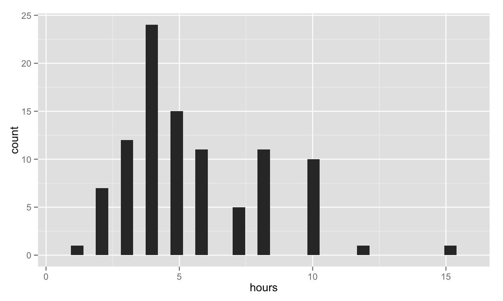

```r
library("ggplot2")
p = ggplot(df, aes(x = hours))
p + geom_histogram()
```

## Work ambition by gender

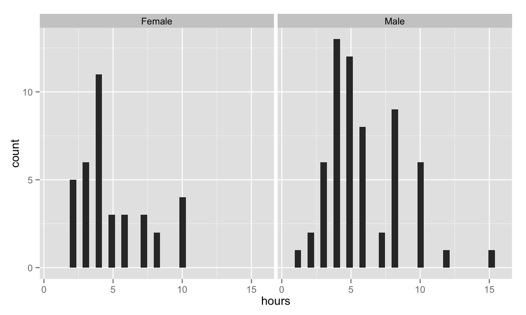

```r
library("ggplot2")
p = ggplot(df, aes(x = hours))
p + geom_histogram() + facet_wrap(~ gender)
```

## Exercise 1

## Exercise 1

- first, try to describe the dataset. What simple commands would you run?
- second, I want you to think about pros and cons of using this kind of data? What should we be worried about when working with this kind of data?
- third, think about interesting questions to ask from the data?
- fourth, to test your R skills, try to answer the following questions
  - what are the dimensions of the data?
  - what are the class of each column?
  - which state has the highest mean marijuana price?

## R skills I

Read the data

```r
library("readr")
my.df = read_csv("https://raw.githubusercontent.com/sebastianbarfort/sds/master/data/marijuana-street-price-clean.csv")
```

```r
dim(my.df)
```

```
## [1] 22899     8
```

```r
names(my.df)
```

```
## [1] "State"  "HighQ"  "HighQN" "MedQ"   "MedQN"  "LowQ"   "LowQN"  "date"
```

```r
summary(my.df)
```

```
##     State               HighQ           HighQN           MedQ
##  Length:22899       Min.   :202.0   Min.   :   93   Min.   :144.8
##  Class :character   1st Qu.:303.8   1st Qu.:  597   1st Qu.:215.8
##  Mode  :character   Median :342.3   Median : 1420   Median :245.8
##                     Mean   :329.8   Mean   : 2275   Mean   :247.6
##                     3rd Qu.:356.6   3rd Qu.: 2958   3rd Qu.:274.2
##                     Max.   :415.7   Max.   :18492   Max.   :379.0
##
##      MedQN            LowQ           LowQN             date
##  Min.   :  134   Min.   : 63.7   Min.   :  11.0   Min.   :2013-12-27
##  1st Qu.:  548   1st Qu.:147.1   1st Qu.:  51.0   1st Qu.:2014-04-18
##  Median : 1320   Median :186.8   Median : 139.0   Median :2014-08-09
##  Mean   : 2184   Mean   :203.7   Mean   : 202.8   Mean   :2014-08-14
##  3rd Qu.: 2673   3rd Qu.:221.4   3rd Qu.: 263.0   3rd Qu.:2014-11-29
##  Max.   :22027   Max.   :734.6   Max.   :1287.0   Max.   :2015-06-11
##                  NA's   :10557
```

## R skills II

For figuring out which state has the highest mean marijuana price we need to look at the `dplyr` package.

Take a look at this package and try if you can figure out how to do this (tip: you need the `group_by` function)

## Highest mean price

```r
library("dplyr")
my.df %>%
  group_by(State) %>%
  summarise(
    m.price = mean(HighQ, na.rm = TRUE)
  ) %>%
  arrange(desc(m.price))
```

```
## Source: local data frame [51 x 2]
##
##           State  m.price
## 1  North Dakota 398.6688
## 2  South Dakota 375.8185
## 3       Vermont 374.2504
## 4      Maryland 370.9852
## 5      Virginia 368.1470
## 6          Iowa 367.0958
## 7     Louisiana 366.8325
## 8      Delaware 366.7818
## 9  Pennsylvania 366.1257
## 10     Oklahoma 361.5731
## ..          ...      ...
```

## The plot code

```r
library("readr")
my.df = read_csv("https://raw.githubusercontent.com/sebastianbarfort/sds/master/data/marijuana-street-price-clean.csv")
```

```r
library("ggplot2")
library("scales")
p = ggplot(my.df, aes(x = date, y = HighQ))
p = p + geom_point(alpha = .05) # add points
p = p + geom_line() # add points
p = p + geom_smooth(colour = "red")
p = p + facet_wrap(~ State, scales = "free_y")
p = p + scale_x_date(breaks = pretty_breaks(4))
p = p + labs(x = NULL, y = "Price ($)", title = "Price of Marijuana")
```

## The plot

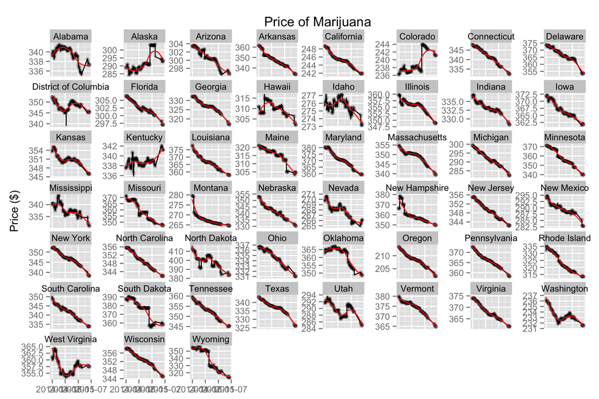